# Project: Investigate a Dataset [TMDB Movie DataAnalysis]

- Introduction
- Data Wrangling
- Exploratory Data Analysis
- Conclusions

## Introduction

### Dataset Description

> This data set is in form of CSV files which is contains information about 10,000 movies collected from The Movie Database (TMDb), including user ratings and revenue.  
> ● Certain columns, like ‘cast’ and ‘genres’, contain multiple values separated by pipe (|) characters.  
> ● There are some odd characters in the ‘cast’ column. Don’t worry about cleaning them. You can leave them as is.  
> ● The final two columns ending with “_adj” show the budget and revenue of the associated movie in terms of 2010 dollars, accounting for inflation ovee time.

### Question(s) for Analysis

1_How many movies increased year by year?  
2_Which genres are most popular from year to year?  
3_What kinds of properties are associated with movies that have high revenues?  
4_Are New Movies longer than they were?

```python
# Use this cell to set up import statements for all of the packages that you plan to use.
import numpy as np
import pandas as pd
import matplotlib.pyplot as plt
import seaborn as sns
% matplotlib inline
```

```python
# Upgrade pandas to use dataframe.explode() function.
#!pip install --upgrade pandas==0.25.0
```

## Data Wrangling

In this section of the report, load the data, check for cleanliness, and then trim and clean your dataset for analysis.

### General Properties

```python
# Loading the data csv file from workspace which is called 'tmbd-movies.csv'
df = pd.read_csv('tmdb-movies.csv')
df.head(3)
```

|  | id | imdb_id | popularity | budget | revenue | original_title | cast | homepage | director | tagline | ... | overview | runtime | genres | production_companies | release_date | vote_count | vote_average | release_year | budget_adj | revenue_adj |
| --- | --- | --- | --- | --- | --- | --- | --- | --- | --- | --- | --- | --- | --- | --- | --- | --- | --- | --- | --- | --- | --- |
| 0 | 135397 | tt0369610 | 32.985763 | 150000000 | 1513528810 | Jurassic World | Chris Pratt\|Bryce Dallas Howard\|Irrfan Khan\|Vi... | http://www.jurassicworld.com/ | Colin Trevorrow | The park is open. | ... | Twenty-two years after the events of Jurassic ... | 124 | Action\|Adventure\|Science Fiction\|Thriller | Universal Studios\|Amblin Entertainment\|Legenda... | 6/9/15 | 5562 | 6.5 | 2015 | 1.379999e+08 | 1.392446e+09 |
| 1 | 76341 | tt1392190 | 28.419936 | 150000000 | 378436354 | Mad Max: Fury Road | Tom Hardy\|Charlize Theron\|Hugh Keays-Byrne\|Nic... | http://www.madmaxmovie.com/ | George Miller | What a Lovely Day. | ... | An apocalyptic story set in the furthest reach... | 120 | Action\|Adventure\|Science Fiction\|Thriller | Village Roadshow Pictures\|Kennedy Miller Produ... | 5/13/15 | 6185 | 7.1 | 2015 | 1.379999e+08 | 3.481613e+08 |
| 2 | 262500 | tt2908446 | 13.112507 | 110000000 | 295238201 | Insurgent | Shailene Woodley\|Theo James\|Kate Winslet\|Ansel... | http://www.thedivergentseries.movie/#insurgent | Robert Schwentke | One Choice Can Destroy You | ... | Beatrice Prior must confront her inner demons ... | 119 | Adventure\|Science Fiction\|Thriller | Summit Entertainment\|Mandeville Films\|Red Wago... | 3/18/15 | 2480 | 6.3 | 2015 | 1.012000e+08 | 2.716190e+08 |

3 rows × 21 columns

```python
df.shape
```

```
(10866, 21)
```

```python
df.describe()
```

|  | id | popularity | budget | revenue | runtime | vote_count | vote_average | release_year | budget_adj | revenue_adj |
| --- | --- | --- | --- | --- | --- | --- | --- | --- | --- | --- |
| count | 10866.000000 | 10866.000000 | 1.086600e+04 | 1.086600e+04 | 10866.000000 | 10866.000000 | 10866.000000 | 10866.000000 | 1.086600e+04 | 1.086600e+04 |
| mean | 66064.177434 | 0.646441 | 1.462570e+07 | 3.982332e+07 | 102.070863 | 217.389748 | 5.974922 | 2001.322658 | 1.755104e+07 | 5.136436e+07 |
| std | 92130.136561 | 1.000185 | 3.091321e+07 | 1.170035e+08 | 31.381405 | 575.619058 | 0.935142 | 12.812941 | 3.430616e+07 | 1.446325e+08 |
| min | 5.000000 | 0.000065 | 0.000000e+00 | 0.000000e+00 | 0.000000 | 10.000000 | 1.500000 | 1960.000000 | 0.000000e+00 | 0.000000e+00 |
| 25% | 10596.250000 | 0.207583 | 0.000000e+00 | 0.000000e+00 | 90.000000 | 17.000000 | 5.400000 | 1995.000000 | 0.000000e+00 | 0.000000e+00 |
| 50% | 20669.000000 | 0.383856 | 0.000000e+00 | 0.000000e+00 | 99.000000 | 38.000000 | 6.000000 | 2006.000000 | 0.000000e+00 | 0.000000e+00 |
| 75% | 75610.000000 | 0.713817 | 1.500000e+07 | 2.400000e+07 | 111.000000 | 145.750000 | 6.600000 | 2011.000000 | 2.085325e+07 | 3.369710e+07 |
| max | 417859.000000 | 32.985763 | 4.250000e+08 | 2.781506e+09 | 900.000000 | 9767.000000 | 9.200000 | 2015.000000 | 4.250000e+08 | 2.827124e+09 |

There is alot of zeros values in this dataset **(Budget, revenue, runtime)** , which represent imprecise vision.  
Also by looking at the min and max value of release year, we found that the movies dataset start from 1960 till 2015 which is covering a huge area of movies and we will divided it into areas leter.  
And by looking at maximum values in runtime it's **(900)** which is very out of range for a movie.

```python
#checking for duplicated rows
df.duplicated().sum()
```

```
1
```

There is only one duplicated row

```python
#checking how many movie is missing its budget.
df[df['budget_adj'] == 0].shape
```

```
(5696, 21)
```

There are 5696 movies missing budget recored

```python
#checking how many movie is missing its runtime value. for sure there is no movie less than 30 mins, so lets check it.
df[df['runtime'] == 0].shape
```

```
(31, 21)
```

31 movies missing duration time.

```python
df.info()
```

```
<class 'pandas.core.frame.DataFrame'>
RangeIndex: 10866 entries, 0 to 10865
Data columns (total 21 columns):
id                      10866 non-null int64
imdb_id                 10856 non-null object
popularity              10866 non-null float64
budget                  10866 non-null int64
revenue                 10866 non-null int64
original_title          10866 non-null object
cast                    10790 non-null object
homepage                2936 non-null object
director                10822 non-null object
tagline                 8042 non-null object
keywords                9373 non-null object
overview                10862 non-null object
runtime                 10866 non-null int64
genres                  10843 non-null object
production_companies    9836 non-null object
release_date            10866 non-null object
vote_count              10866 non-null int64
vote_average            10866 non-null float64
release_year            10866 non-null int64
budget_adj              10866 non-null float64
revenue_adj             10866 non-null float64
dtypes: float64(4), int64(6), object(11)
memory usage: 1.7+ MB
```

After looking at this informarion, we figure out thats the release_date not in timedate format.

```python
# checking for numbers of Null values in each feature.
df.isnull().sum()
```

```
id                         0
imdb_id                   10
popularity                 0
budget                     0
revenue                    0
original_title             0
cast                      76
homepage                7930
director                  44
tagline                 2824
keywords                1493
overview                   4
runtime                    0
genres                    23
production_companies    1030
release_date               0
vote_count                 0
vote_average               0
release_year               0
budget_adj                 0
revenue_adj                0
dtype: int64
```

There is a lot of missing values in those features **['homepage', 'tagline', 'keywords', 'production_companies']**

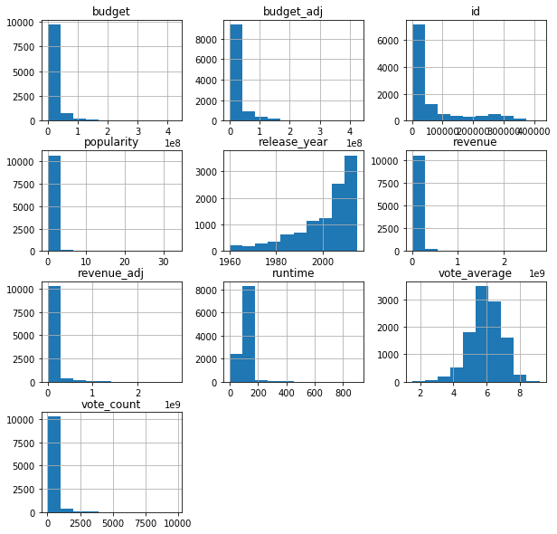

```python
df.hist(figsize=(10,10));
```

# Data Accessing & Inspecting Summarize

After collecting and loading our data from csv file and take a general look at it, we figure out that this dataset needs some cleanings.  
Removing duplicated rows.  
Droping unneeded columns.  
Removing zeros rows in runtime.  
Changing the revenues and budget type to int to remove the useless fraction.

### Data Cleaning

lets begin with drop the useless columns in our dataset to reduce and clarify it.  
drop budget and revenue and leave the adjusted one.

```python
#droping the useless columns (id,imdb_id,budget,revenue,homepage,tagline,keywords,overview,release_date)
df.drop(['id', 'imdb_id', 'budget', 'revenue', 'homepage', 'tagline', 'keywords', 'overview','release_date'], axis=1, inplace=True)
```

```python
#checking of droping columns is done
df.shape
```

```
(10866, 12)
```

```python
#droping the dupulicated row
df.drop_duplicates(inplace=True)
```

```python
#checking for duplicated rows
df.duplicated().sum()
```

```
0
```

```python
df.isnull().sum()
```

```
popularity                 0
original_title             0
cast                      76
director                  44
runtime                    0
genres                    23
production_companies    1030
vote_count                 0
vote_average               0
release_year               0
budget_adj                 0
revenue_adj                0
dtype: int64
```

Now this null values won't effect our exploratory and no need to drop or try to fill it.

```python
#droping the 31 rows thats contains the zeros value in movie runtime.
df.drop(df.index[df['runtime'] == 0], inplace=True)
```

```python
#changing the budget and revenue data type to remove the unimportant fractions.
df['revenue_adj'] = df['revenue_adj'].astype(int)
df['budget_adj'] = df['budget_adj'].astype(int)
```

```python
#checking for the type of the revenue and budget type
df.revenue_adj.dtypes, df.budget_adj.dtypes
```

```
(dtype('int64'), dtype('int64'))
```

changing the budget and revenue data type to remove the unimportant fractions.

# To Summarize Wrangling

### After collecting and loading our data from csv file and take a general look at the dataset to recognize my data. i started with cleaning the data to clarify my answers.

## Exploratory Data Analysis

# general look

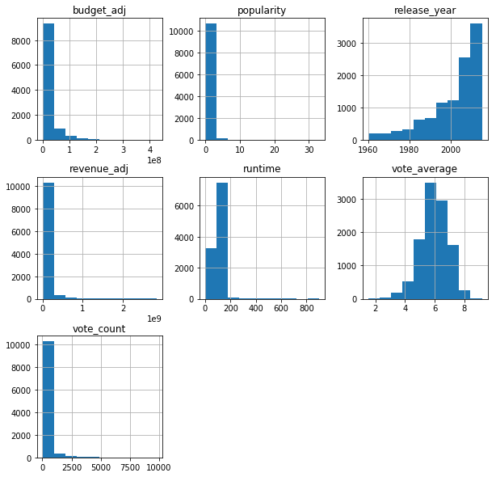

```python
df.hist(figsize=(10,10));
```

**As shown here in the release_year the number of movies increaced in early years after 1995**

```python
df.describe()
```

|  | popularity | runtime | vote_count | vote_average | release_year | budget_adj | revenue_adj |
| --- | --- | --- | --- | --- | --- | --- | --- |
| count | 10834.000000 | 10834.000000 | 10834.000000 | 10834.000000 | 10834.000000 | 1.083400e+04 | 1.083400e+04 |
| mean | 0.647762 | 102.363855 | 217.962064 | 5.976343 | 2001.295274 | 1.759896e+07 | 5.151599e+07 |
| std | 1.001204 | 30.948225 | 576.370933 | 0.935047 | 12.819708 | 3.434421e+07 | 1.448190e+08 |
| min | 0.000065 | 2.000000 | 10.000000 | 1.500000 | 1960.000000 | 0.000000e+00 | 0.000000e+00 |
| 25% | 0.208536 | 90.000000 | 17.000000 | 5.400000 | 1995.000000 | 0.000000e+00 | 0.000000e+00 |
| 50% | 0.384690 | 99.000000 | 38.000000 | 6.000000 | 2006.000000 | 0.000000e+00 | 0.000000e+00 |
| 75% | 0.715448 | 112.000000 | 146.000000 | 6.600000 | 2011.000000 | 2.094246e+07 | 3.389667e+07 |
| max | 32.985763 | 900.000000 | 9767.000000 | 9.200000 | 2015.000000 | 4.250000e+08 | 2.827124e+09 |

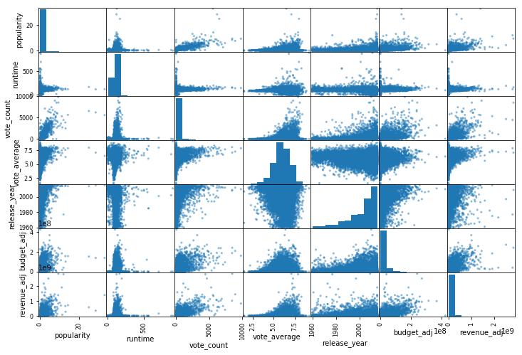

```python
pd.plotting.scatter_matrix(df, figsize=(12,8));
```

### Research Question 1 (How many movies increased year by year?)

```python
#define an variable which include the range of the decades in movie release year range.
year_areas = [1960,1970,1980,1990,2000,2015]
```

```python
#define new variable for lables
areas_names = ['60s', '70s', '80s', '90s','2000s']
```

```python
#Here I used a cut function to extract the years area from the total dataframe and put it in new feature called "area"
df['area'] = pd.cut(df['release_year'], year_areas, labels=areas_names)
```

```python
#checking the new column "area"
df.head()
```

|  | popularity | original_title | cast | director | runtime | genres | production_companies | vote_count | vote_average | release_year | budget_adj | revenue_adj | area |
| --- | --- | --- | --- | --- | --- | --- | --- | --- | --- | --- | --- | --- | --- |
| 0 | 32.985763 | Jurassic World | Chris Pratt\|Bryce Dallas Howard\|Irrfan Khan\|Vi... | Colin Trevorrow | 124 | Action\|Adventure\|Science Fiction\|Thriller | Universal Studios\|Amblin Entertainment\|Legenda... | 5562 | 6.5 | 2015 | 137999939 | 1392445892 | 2000s |
| 1 | 28.419936 | Mad Max: Fury Road | Tom Hardy\|Charlize Theron\|Hugh Keays-Byrne\|Nic... | George Miller | 120 | Action\|Adventure\|Science Fiction\|Thriller | Village Roadshow Pictures\|Kennedy Miller Produ... | 6185 | 7.1 | 2015 | 137999939 | 348161292 | 2000s |
| 2 | 13.112507 | Insurgent | Shailene Woodley\|Theo James\|Kate Winslet\|Ansel... | Robert Schwentke | 119 | Adventure\|Science Fiction\|Thriller | Summit Entertainment\|Mandeville Films\|Red Wago... | 2480 | 6.3 | 2015 | 101199955 | 271619025 | 2000s |
| 3 | 11.173104 | Star Wars: The Force Awakens | Harrison Ford\|Mark Hamill\|Carrie Fisher\|Adam D... | J.J. Abrams | 136 | Action\|Adventure\|Science Fiction\|Fantasy | Lucasfilm\|Truenorth Productions\|Bad Robot | 5292 | 7.5 | 2015 | 183999919 | 1902723129 | 2000s |
| 4 | 9.335014 | Furious 7 | Vin Diesel\|Paul Walker\|Jason Statham\|Michelle ... | James Wan | 137 | Action\|Crime\|Thriller | Universal Pictures\|Original Film\|Media Rights ... | 2947 | 7.3 | 2015 | 174799923 | 1385748801 | 2000s |

```python
#Displaying the values(number of movies) of each decad.
df.area.value_counts()
```

```
2000s    6910
90s      1859
80s      1117
70s       545
60s       371
Name: area, dtype: int64
```

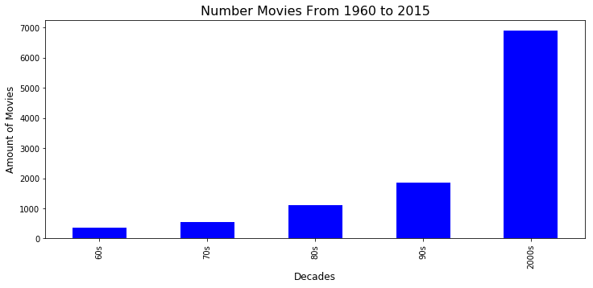

```python
plt.figure(figsize=(12,5))
df.groupby('area')['area'].count().plot(kind='bar',color = 'b')
plt.title('Number Movies From 1960 to 2015', fontsize=(16))
plt.xlabel('Decades', fontsize=(12))
plt.ylabel('Amount of Movies', fontsize=(12));
```

### Research Question 2 (Which genres are most popular from year to year?)

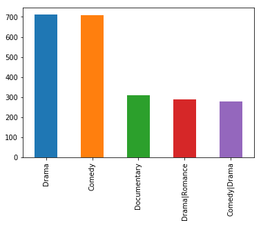

```python
df.genres.value_counts().head().plot(kind='bar');
```

As shown here the **Drama** is the most frequent genres over the most of movies and decades.

```python
area60s = df[df['area']=='60s'].genres.value_counts()
area60s.head()
```

```
Drama             25
Horror            17
Comedy            14
Comedy|Romance    13
Drama|Romance     12
Name: genres, dtype: int64
```

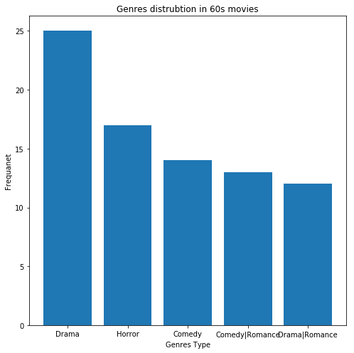

```python
locations = [1, 2, 3, 4, 5]
heights = [area60s[0], area60s[1], area60s[2], area60s[3], area60s[4]]
labels = [area60s.index[0], area60s.index[1], area60s.index[2], area60s.index[3], area60s.index[4]]
plt.figure(figsize=(8,8))
plt.bar(locations, heights, tick_label=labels)
plt.title('Genres distrubtion in 60s movies')
plt.xlabel('Genres Type')
plt.ylabel('Frequanet');
```

This graph shows us that in the 60s the **Drama** is the highest movie genre.

```python
area90s = df[df['area']=='90s'].genres.value_counts()
area90s.head()
```

```
Comedy                  117
Drama                    99
Drama|Romance            69
Comedy|Drama             65
Comedy|Drama|Romance     52
Name: genres, dtype: int64
```

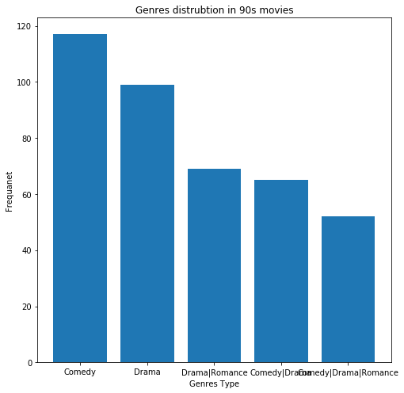

```python
locations = [1, 2, 3, 4, 5]
heights = [area90s[0], area90s[1], area90s[2], area90s[3], area90s[4]]
labels = [area90s.index[0], area90s.index[1], area90s.index[2], area90s.index[3], area90s.index[4]]
plt.figure(figsize=(8,8))
plt.bar(locations, heights, tick_label=labels)
plt.title('Genres distrubtion in 90s movies')
plt.xlabel('Genres Type')
plt.ylabel('Frequanet');
```

This graph shows us that in the 90s the **Comedy** is the highest movie genre.

```python
area2000s = df[df['area']=='2000s'].genres.value_counts()
area2000s.head()
```

```
Drama              506
Comedy             472
Documentary        288
Horror|Thriller    192
Drama|Romance      175
Name: genres, dtype: int64
```

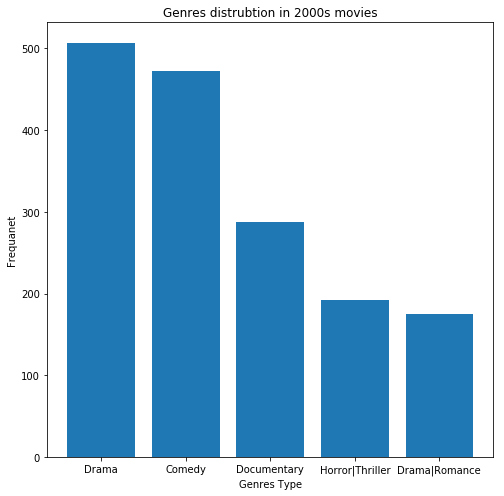

```python
locations = [1, 2, 3, 4, 5]
heights = [area2000s[0], area2000s[1], area2000s[2], area2000s[3], area2000s[4]]
labels = [area2000s.index[0], area2000s.index[1], area2000s.index[2], area2000s.index[3], area2000s.index[4]]
plt.figure(figsize=(8,8))
plt.bar(locations, heights, tick_label=labels)
plt.title('Genres distrubtion in 2000s movies')
plt.xlabel('Genres Type')
plt.ylabel('Frequanet');
```

The showen the pervious garphs the documenrtary genres mostly appears in the last decade.

```python
#Checking the number of movies that exceeding the 3.5 hours, and also the moveis that less than 30 mins.
df[df['runtime'] >= 210].count().sum(),df[df['runtime'] <= 30].count().sum()
```

```
(808, 2640)
```

then i will classify the movies into **Long movies, movies, and short films**.

```python
#defineing a new variables to classify accourding to the movie duration.
long_movies = df.runtime >= 210
movies = (df.runtime >30) & (df.runtime < 210)
short_films = df.runtime <= 30
```

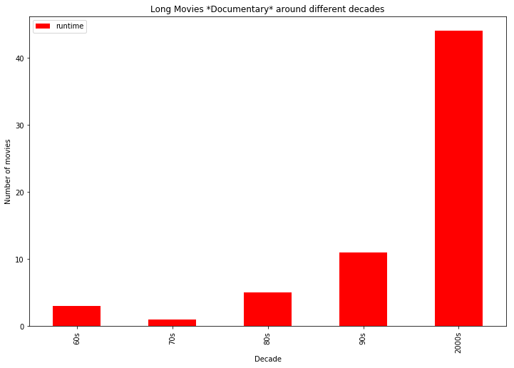

```python
#trying to plot the difference between the movies duration over decades.
plt.figure(figsize=[12,8])
df[long_movies].groupby('area').runtime.count().plot(kind='bar', alpha= 1, color = 'r')
plt.legend()
plt.xlabel('Decade')
plt.ylabel('Number of movies')
plt.title('Long Movies *Documentary* around different decades');
```

### Research Question 3 (What kinds of properties are associated with movies that have high revenues?)

```python
#defining a new variable contain the Non zero values in revenues & budget.
clear_revenue = (df.revenue_adj != 0) & (df.budget_adj != 0)
```

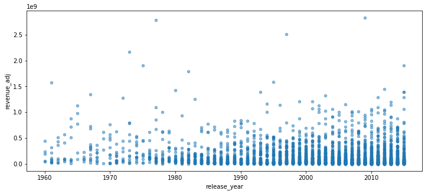

[figure not shown]

```python
#plotting the revenue and budget garph to inspect if there any common feature between both of them.
df[clear_revenue].plot(kind='scatter', x='release_year', y='revenue_adj', alpha=.5, figsize=(12,5))
df[clear_revenue].plot(kind='scatter', x='release_year', y='budget_adj', alpha=.5, figsize=(12,5))
plt.ylabel('revenue_adj')
plt.title('Scatter Plot');
```

```python
#Checking the average of revenue between two different decades to make sure of the data above.
df[df['area']=='60s'].revenue_adj.mean() > df[df['area']=='2000s'].revenue_adj.mean()
```

```
True
```

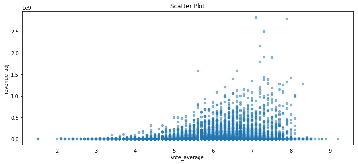

```python
#plotting the revenue with voting garph to inspect if there any common feature between both of them.
df.plot(kind='scatter', x='vote_average', y='revenue_adj', alpha=.5, figsize=(12,5))
plt.ylabel('revenue_adj')
plt.title('Scatter Plot');
```

```python
df.vote_average.describe()
```

```
count    10834.000000
mean         5.976343
std          0.935047
min          1.500000
25%          5.400000
50%          6.000000
75%          6.600000
max          9.200000
Name: vote_average, dtype: float64
```

As shown here in the pervious garph which represent positive trend.  
that the majoirty of revenues are increasing after 25% of the vote which is starting from (5.4) to 8.

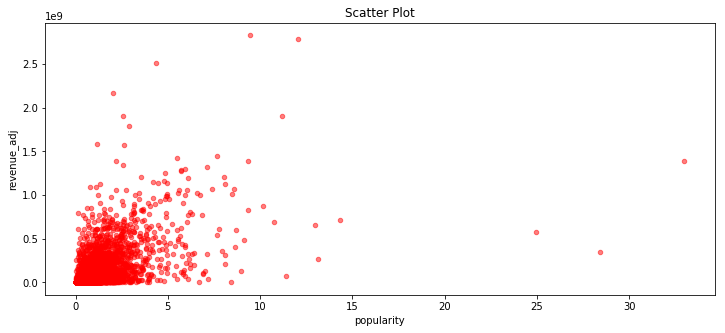

```python
df.plot(kind='scatter', x='popularity', y='revenue_adj', alpha=.5, color='r', figsize=(12,5))
plt.ylabel('revenue_adj')
plt.title('Scatter Plot');
```

```python
df.popularity.describe()
```

```
count    10834.000000
mean         0.647762
std          1.001204
min          0.000065
25%          0.208536
50%          0.384690
75%          0.715448
max         32.985763
Name: popularity, dtype: float64
```

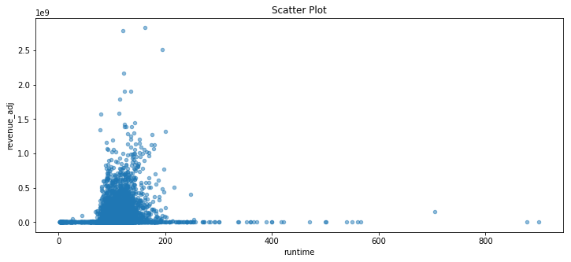

```python
df.plot(kind='scatter', x='runtime', y='revenue_adj', alpha=.5, figsize=(12,5))
plt.ylabel('revenue_adj')
plt.title('Scatter Plot')
plt.show()
```

```python
df.runtime.describe()
```

```
count    10834.000000
mean       102.363855
std         30.948225
min          2.000000
25%         90.000000
50%         99.000000
75%        112.000000
max        900.000000
Name: runtime, dtype: float64
```

The runtime graph with revenues here shows that the highly area of revenues in the range from **90 mins** movies to **200 mins** movies

### Research Question 4 (Are New Movies longer than they were?)

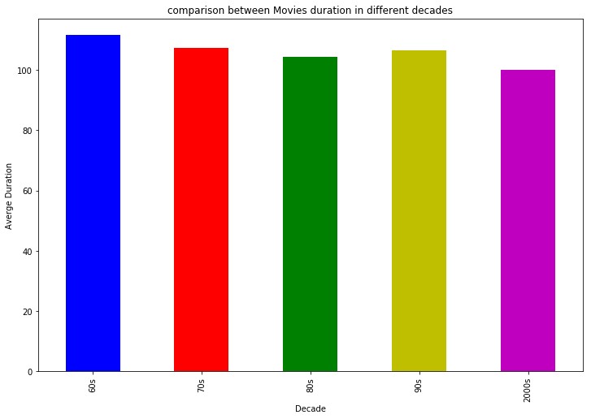

```python
#plotting average runtime in each decade to show the difference
plt.figure(figsize=[12,8])
df[df['area']=='60s'].groupby('area').runtime.mean().plot(kind='bar',color = 'b')
df[df['area']=='70s'].groupby('area').runtime.mean().plot(kind='bar',color = 'r')
df[df['area']=='80s'].groupby('area').runtime.mean().plot(kind='bar',color = 'g')
df[df['area']=='90s'].groupby('area').runtime.mean().plot(kind='bar',color = 'y')
df[df['area']=='2000s'].groupby('area').runtime.mean().plot(kind='bar',color = 'm')
plt.xlabel('Decade')
plt.ylabel('Averge Duration')
plt.title('comparison between Movies duration in different decades');
```

Actually, The anwser of the last quesiton is **NO**, the average of runtime in order from old movies to the new movies is decreased little bit.

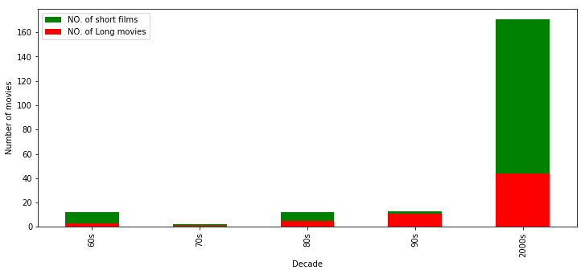

```python
#plotting a graph to show the amount of short and long movies in different decades.
plt.figure(figsize=[12,5])
df[short_films].groupby('area').runtime.count().plot(kind='bar',color = 'g',label='NO. of short films')
df[long_movies].groupby('area').runtime.count().plot(kind='bar',color = 'r',label='NO. of Long movies')
plt.legend()
plt.xlabel('Decade')
plt.ylabel('Number of movies');
```

As you can see here the number of **short films** which there duration less than 30 mins is the majority of the distribution. And aslo we can see the number of **long moveis** increased in the last decade.

## Submitting your Project

After concluding the second question we figure out that the **Drama** movies genres are the most frequent genres over the years, except in the 90s decade the **Comedy** genres go one better than **Drama**.  
And also we found a new type that appears which is **Documentary** movies type.

The comparison between average runtime and decades in order from old movies to the new movies shows that it is decreased a little bit.

### The Limitation

```python
from subprocess import call
call(['python', '-m', 'nbconvert', 'Investigate_a_Dataset.ipynb'])
```

```
0
```